# CAPSTONE

```python
import pandas as pd
```

IMPORTING NCBIRTHS DATA AND ITS INFORMATION

```python
data = pd.read_csv("ncbirths.csv")
```

```python
data
```

|  | fage | mage | mature | weeks | premie | visits | marital | gained | weight | lowbirthweight | gender | habit | whitemom |
| --- | --- | --- | --- | --- | --- | --- | --- | --- | --- | --- | --- | --- | --- |
| 0 | NaN | 13 | younger mom | 39.0 | full term | 10.0 | not married | 38.0 | 7.63 | not low | male | nonsmoker | not white |
| 1 | NaN | 14 | younger mom | 42.0 | full term | 15.0 | not married | 20.0 | 7.88 | not low | male | nonsmoker | not white |
| 2 | 19.0 | 15 | younger mom | 37.0 | full term | 11.0 | not married | 38.0 | 6.63 | not low | female | nonsmoker | white |
| 3 | 21.0 | 15 | younger mom | 41.0 | full term | 6.0 | not married | 34.0 | 8.00 | not low | male | nonsmoker | white |
| 4 | NaN | 15 | younger mom | 39.0 | full term | 9.0 | not married | 27.0 | 6.38 | not low | female | nonsmoker | not white |
| ... | ... | ... | ... | ... | ... | ... | ... | ... | ... | ... | ... | ... | ... |
| 995 | 47.0 | 42 | mature mom | 40.0 | full term | 10.0 | married | 26.0 | 8.44 | not low | male | nonsmoker | not white |
| 996 | 34.0 | 42 | mature mom | 38.0 | full term | 18.0 | married | 20.0 | 6.19 | not low | female | nonsmoker | white |
| 997 | 39.0 | 45 | mature mom | 40.0 | full term | 15.0 | married | 32.0 | 6.94 | not low | female | nonsmoker | white |
| 998 | 55.0 | 46 | mature mom | 31.0 | premie | 8.0 | married | 25.0 | 4.56 | low | female | nonsmoker | not white |
| 999 | 45.0 | 50 | mature mom | 39.0 | full term | 14.0 | married | 23.0 | 7.13 | not low | female | nonsmoker | white |

1000 rows × 13 columns

```python
data.isnull().sum()
```

```
fage              171
mage                0
mature              0
weeks               2
premie              2
visits              9
marital             1
gained             27
weight              0
lowbirthweight      0
gender              0
habit               1
whitemom            2
dtype: int64
```

DATA CLEANING

Since the fage column is considered to be a control variable and has nulls, it is being dropped

```python
df1 = data.drop(columns=["fage"])
df1.head()
```

|  | mage | mature | weeks | premie | visits | marital | gained | weight | lowbirthweight | gender | habit | whitemom |
| --- | --- | --- | --- | --- | --- | --- | --- | --- | --- | --- | --- | --- |
| 0 | 13 | younger mom | 39.0 | full term | 10.0 | not married | 38.0 | 7.63 | not low | male | nonsmoker | not white |
| 1 | 14 | younger mom | 42.0 | full term | 15.0 | not married | 20.0 | 7.88 | not low | male | nonsmoker | not white |
| 2 | 15 | younger mom | 37.0 | full term | 11.0 | not married | 38.0 | 6.63 | not low | female | nonsmoker | white |
| 3 | 15 | younger mom | 41.0 | full term | 6.0 | not married | 34.0 | 8.00 | not low | male | nonsmoker | white |
| 4 | 15 | younger mom | 39.0 | full term | 9.0 | not married | 27.0 | 6.38 | not low | female | nonsmoker | not white |

Removing null values in weeks,visits,gained columns and imputing missing values using median()

```python
df1['weeks'].fillna(df1['weeks'].median(), inplace=True)
df1['visits'].fillna(df1['visits'].median(), inplace=True)
df1['gained'].fillna(df1['gained'].median(), inplace=True)
```

Removing null values in premie,marital,habit,whitemom columns and imputing missing values using mode()

```python
df1['premie'].fillna(df1['premie'].mode()[0], inplace=True)
df1['marital'].fillna(df1['marital'].mode()[0], inplace=True)
df1['habit'].fillna(df1['habit'].mode()[0], inplace=True)
df1['whitemom'].fillna(df1['whitemom'].mode()[0], inplace=True)
```

```python
df1.isnull().sum()
```

```
mage              0
mature            0
weeks             0
premie            0
visits            0
marital           0
gained            0
weight            0
lowbirthweight    0
gender            0
habit             0
whitemom          0
dtype: int64
```

```python
df1.nunique()
```

```
mage               33
mature              2
weeks              23
premie              2
visits             26
marital             2
gained             71
weight            126
lowbirthweight      2
gender              2
habit               2
whitemom            2
dtype: int64
```

```python
df1.info()
```

```
<class 'pandas.core.frame.DataFrame'>
RangeIndex: 1000 entries, 0 to 999
Data columns (total 12 columns):
 #   Column          Non-Null Count  Dtype
---  ------          --------------  -----
 0   mage            1000 non-null   int64
 1   mature          1000 non-null   object
 2   weeks           1000 non-null   float64
 3   premie          1000 non-null   object
 4   visits          1000 non-null   float64
 5   marital         1000 non-null   object
 6   gained          1000 non-null   float64
 7   weight          1000 non-null   float64
 8   lowbirthweight  1000 non-null   object
 9   gender          1000 non-null   object
 10  habit           1000 non-null   object
 11  whitemom        1000 non-null   object
dtypes: float64(4), int64(1), object(7)
memory usage: 93.9+ KB
```

df1 is a cleaned dataset and has 1000 rows x 12 columns

RENAMING COLUMNS

```python
df1.rename(columns={
    'mage': 'Mother_Age',
    'mature': 'Mother_Maturity',
    'weeks': 'Gestation_Weeks',
    'premie': 'Birth_Term',
    'visits': 'Prenatal_Visits',
    'marital': 'Marital_Status',
    'gained': 'Mother_Weight_Gained',
    'weight': 'Baby_Weight',
    'lowbirthweight': 'Baby_Weight_Category',
    'gender': 'Baby_Gender',
    'habit': 'Smoking_Status'
}, inplace=True)
```

```python
df = df1
df
```

|  | Mother_Age | Mother_Maturity | Gestation_Weeks | Birth_Term | Prenatal_Visits | Marital_Status | Mother_Weight_Gained | Baby_Weight | Baby_Weight_Category | Baby_Gender | Smoking_Status | whitemom |
| --- | --- | --- | --- | --- | --- | --- | --- | --- | --- | --- | --- | --- |
| 0 | 13 | younger mom | 39.0 | full term | 10.0 | not married | 38.0 | 7.63 | not low | male | nonsmoker | not white |
| 1 | 14 | younger mom | 42.0 | full term | 15.0 | not married | 20.0 | 7.88 | not low | male | nonsmoker | not white |
| 2 | 15 | younger mom | 37.0 | full term | 11.0 | not married | 38.0 | 6.63 | not low | female | nonsmoker | white |
| 3 | 15 | younger mom | 41.0 | full term | 6.0 | not married | 34.0 | 8.00 | not low | male | nonsmoker | white |
| 4 | 15 | younger mom | 39.0 | full term | 9.0 | not married | 27.0 | 6.38 | not low | female | nonsmoker | not white |
| ... | ... | ... | ... | ... | ... | ... | ... | ... | ... | ... | ... | ... |
| 995 | 42 | mature mom | 40.0 | full term | 10.0 | married | 26.0 | 8.44 | not low | male | nonsmoker | not white |
| 996 | 42 | mature mom | 38.0 | full term | 18.0 | married | 20.0 | 6.19 | not low | female | nonsmoker | white |
| 997 | 45 | mature mom | 40.0 | full term | 15.0 | married | 32.0 | 6.94 | not low | female | nonsmoker | white |
| 998 | 46 | mature mom | 31.0 | premie | 8.0 | married | 25.0 | 4.56 | low | female | nonsmoker | not white |
| 999 | 50 | mature mom | 39.0 | full term | 14.0 | married | 23.0 | 7.13 | not low | female | nonsmoker | white |

1000 rows × 12 columns

df is a cleaned dataset with columns renamed for better understanding

CALCULATED FIELD

```python
df['Weight_Gain_per_Week'] = df['Mother_Weight_Gained'] / df['Gestation_Weeks']
df['Weight_Gain_per_Week']
```

```
0      0.974359
1      0.476190
2      1.027027
3      0.829268
4      0.692308
         ...
995    0.650000
996    0.526316
997    0.800000
998    0.806452
999    0.589744
Name: Weight_Gain_per_Week, Length: 1000, dtype: float64
```

```python
df
```

|  | Mother_Age | Mother_Maturity | Gestation_Weeks | Birth_Term | Prenatal_Visits | Marital_Status | Mother_Weight_Gained | Baby_Weight | Baby_Weight_Category | Baby_Gender | Smoking_Status | whitemom | Weight_Gain_per_Week |
| --- | --- | --- | --- | --- | --- | --- | --- | --- | --- | --- | --- | --- | --- |
| 0 | 13 | younger mom | 39.0 | full term | 10.0 | not married | 38.0 | 7.63 | not low | male | nonsmoker | not white | 0.974359 |
| 1 | 14 | younger mom | 42.0 | full term | 15.0 | not married | 20.0 | 7.88 | not low | male | nonsmoker | not white | 0.476190 |
| 2 | 15 | younger mom | 37.0 | full term | 11.0 | not married | 38.0 | 6.63 | not low | female | nonsmoker | white | 1.027027 |
| 3 | 15 | younger mom | 41.0 | full term | 6.0 | not married | 34.0 | 8.00 | not low | male | nonsmoker | white | 0.829268 |
| 4 | 15 | younger mom | 39.0 | full term | 9.0 | not married | 27.0 | 6.38 | not low | female | nonsmoker | not white | 0.692308 |
| ... | ... | ... | ... | ... | ... | ... | ... | ... | ... | ... | ... | ... | ... |
| 995 | 42 | mature mom | 40.0 | full term | 10.0 | married | 26.0 | 8.44 | not low | male | nonsmoker | not white | 0.650000 |
| 996 | 42 | mature mom | 38.0 | full term | 18.0 | married | 20.0 | 6.19 | not low | female | nonsmoker | white | 0.526316 |
| 997 | 45 | mature mom | 40.0 | full term | 15.0 | married | 32.0 | 6.94 | not low | female | nonsmoker | white | 0.800000 |
| 998 | 46 | mature mom | 31.0 | premie | 8.0 | married | 25.0 | 4.56 | low | female | nonsmoker | not white | 0.806452 |
| 999 | 50 | mature mom | 39.0 | full term | 14.0 | married | 23.0 | 7.13 | not low | female | nonsmoker | white | 0.589744 |

1000 rows × 13 columns

ENCODING VARIABLES AND DATA VISUALIZATION

```python
import seaborn as sns
import matplotlib.pyplot as plt
```

1. Histogram

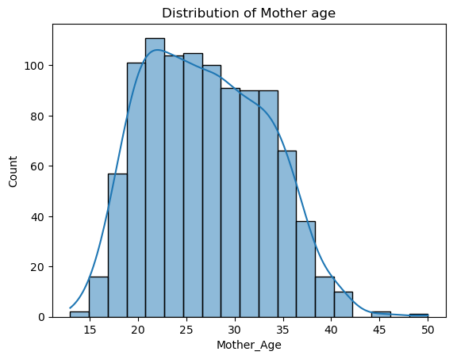

```python
sns.histplot(df['Mother_Age'], kde = 'True')
plt.title('Distribution of Mother age')
plt.show()
```

Interpretation: Mother’s age follows a right-skewed distribution, with most mothers aged between 20 and 35 years. There are fewer younger (<18) and older (>40) mothers in the dataset, which may influence how maternal age affects outcomes like birth weight.

2. Scatter Plot

```python
df['Baby_Weight_Category'] = df['Baby_Weight_Category'].replace({
    'low': 'Lower Baby Weight',
    'not low': 'Normal Baby Weight'
})
```

```python
df['Baby_Weight_Category'].value_counts()
```

```
Baby_Weight_Category
Normal Baby Weight    889
Lower Baby Weight     111
Name: count, dtype: int64
```

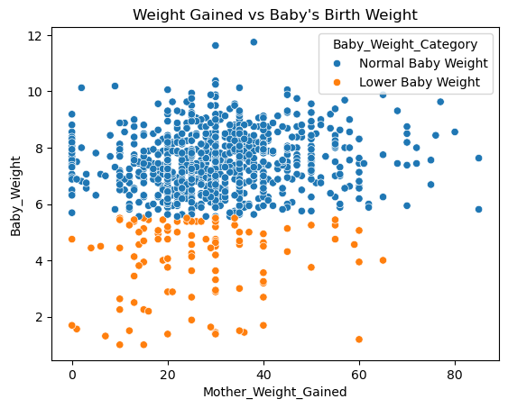

```python
sns.scatterplot(x='Mother_Weight_Gained', y='Baby_Weight', hue='Baby_Weight_Category', data=df)
plt.title("Weight Gained vs Baby's Birth Weight")
plt.show()
```

Interpretation: There’s a visible separation between lower and normal baby weight categories. Mothers who gained more weight during pregnancy tend to have babies in the normal weight range.

3. Barplot

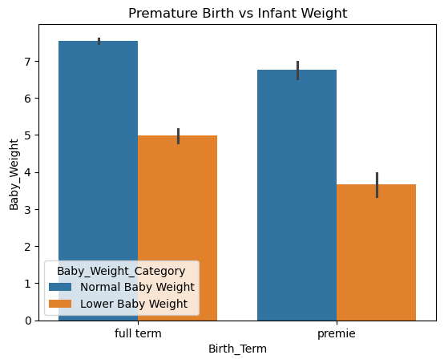

```python
sns.barplot(x='Birth_Term', y='Baby_Weight', hue='Baby_Weight_Category', data=df)
plt.title("Premature Birth vs Infant Weight")
plt.show()
```

Interpretation: Infants born prematurely (premie) have a visibly lower average birth weight, especially among those classified as "Lower Baby Weight." This supports the well-established finding that premature delivery is a major risk factor for low birth weight.

4. Boxplot

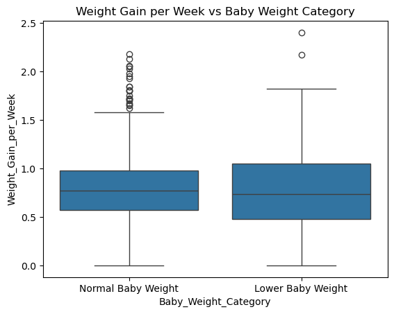

```python
sns.boxplot(x='Baby_Weight_Category', y='Weight_Gain_per_Week', data=df)
plt.title("Weight Gain per Week vs Baby Weight Category")
plt.show()
```

Interpretation: The boxplot shows that mothers with normal-weight babies generally gained slightly more weight per week than those with lower-weight babies. The median is higher for the normal group, and more high outliers are present.

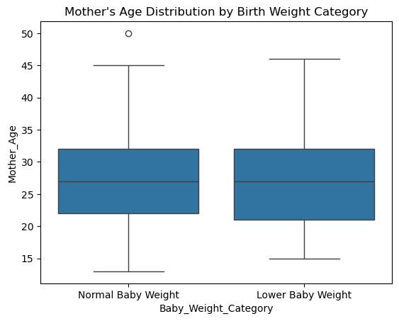

```python
sns.boxplot(x='Baby_Weight_Category', y='Mother_Age', data=df)
plt.title("Mother's Age Distribution by Birth Weight Category")
plt.show()
```

Interpretation: The distribution of maternal age appears similar across both baby weight categories. Median age and spread are nearly identical, suggesting no strong association between maternal age and low birth weight in this sample.

5. Heatmap

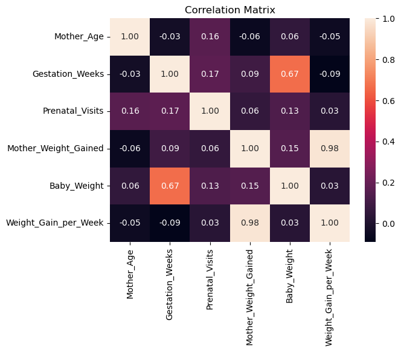

```python
sns.heatmap(df.select_dtypes(include='number').corr(), annot=True, fmt='.2f')
plt.title("Correlation Matrix")
plt.show()
```

Interpretation: The correlation matrix shows a moderate positive correlation (0.67) between gestational weeks and baby weight, suggesting that longer pregnancies are associated with higher birth weights. Other variables like prenatal visits and maternal weight gain show weak correlations with baby weight, indicating they may have a smaller individual effect.

DESCRIPTIVE STATISTCS

```python
df.describe()
```

|  | Mother_Age | Gestation_Weeks | Prenatal_Visits | Mother_Weight_Gained | Baby_Weight | Weight_Gain_per_Week |
| --- | --- | --- | --- | --- | --- | --- |
| count | 1000.000000 | 1000.000000 | 1000.000000 | 1000.000000 | 1000.00000 | 1000.000000 |
| mean | 27.000000 | 38.336000 | 12.104000 | 30.317000 | 7.10100 | 0.793349 |
| std | 6.213583 | 2.928768 | 3.937091 | 14.047628 | 1.50886 | 0.370135 |
| min | 13.000000 | 20.000000 | 0.000000 | 0.000000 | 1.00000 | 0.000000 |
| 25% | 22.000000 | 37.000000 | 10.000000 | 21.000000 | 6.38000 | 0.555556 |
| 50% | 27.000000 | 39.000000 | 12.000000 | 30.000000 | 7.31000 | 0.769231 |
| 75% | 32.000000 | 40.000000 | 15.000000 | 38.000000 | 8.06000 | 0.975610 |
| max | 50.000000 | 45.000000 | 30.000000 | 85.000000 | 11.75000 | 2.400000 |

DETECTING AND REMOVING OUTLIERS

```python
column = 'Weight_Gain_per_Week'
```

```python
Q1 = df[column].quantile(0.25)
Q3 = df[column].quantile(0.75)
IQR = Q3 - Q1
```

```python
lower_bound = Q1 - 2.5 * IQR
upper_bound = Q3 + 2.5 * IQR
```

```python
df['Weight_Gain_per_Week'] = df['Weight_Gain_per_Week'].clip(lower_bound, upper_bound)
```

```python
from scipy.stats import zscore
import numpy as np
z_scores = zscore(df['Weight_Gain_per_Week'])
df_no_outliers = df[(np.abs(z_scores) < 3)]
```

```python
df_no_outliers
```

|  | Mother_Age | Mother_Maturity | Gestation_Weeks | Birth_Term | Prenatal_Visits | Marital_Status | Mother_Weight_Gained | Baby_Weight | Baby_Weight_Category | Baby_Gender | Smoking_Status | whitemom | Weight_Gain_per_Week |
| --- | --- | --- | --- | --- | --- | --- | --- | --- | --- | --- | --- | --- | --- |
| 0 | 13 | younger mom | 39.0 | full term | 10.0 | not married | 38.0 | 7.63 | Normal Baby Weight | male | nonsmoker | not white | 0.974359 |
| 1 | 14 | younger mom | 42.0 | full term | 15.0 | not married | 20.0 | 7.88 | Normal Baby Weight | male | nonsmoker | not white | 0.476190 |
| 2 | 15 | younger mom | 37.0 | full term | 11.0 | not married | 38.0 | 6.63 | Normal Baby Weight | female | nonsmoker | white | 1.027027 |
| 3 | 15 | younger mom | 41.0 | full term | 6.0 | not married | 34.0 | 8.00 | Normal Baby Weight | male | nonsmoker | white | 0.829268 |
| 4 | 15 | younger mom | 39.0 | full term | 9.0 | not married | 27.0 | 6.38 | Normal Baby Weight | female | nonsmoker | not white | 0.692308 |
| ... | ... | ... | ... | ... | ... | ... | ... | ... | ... | ... | ... | ... | ... |
| 995 | 42 | mature mom | 40.0 | full term | 10.0 | married | 26.0 | 8.44 | Normal Baby Weight | male | nonsmoker | not white | 0.650000 |
| 996 | 42 | mature mom | 38.0 | full term | 18.0 | married | 20.0 | 6.19 | Normal Baby Weight | female | nonsmoker | white | 0.526316 |
| 997 | 45 | mature mom | 40.0 | full term | 15.0 | married | 32.0 | 6.94 | Normal Baby Weight | female | nonsmoker | white | 0.800000 |
| 998 | 46 | mature mom | 31.0 | premie | 8.0 | married | 25.0 | 4.56 | Lower Baby Weight | female | nonsmoker | not white | 0.806452 |
| 999 | 50 | mature mom | 39.0 | full term | 14.0 | married | 23.0 | 7.13 | Normal Baby Weight | female | nonsmoker | white | 0.589744 |

990 rows × 13 columns

FEATURE SELECTION

```python
df.rename(columns={
    'whitemom': 'Race',
}, inplace=True)
```

```python
df['Baby_Weight_Category'] = df['Baby_Weight_Category'].replace({'Normal Baby Weight': 0, 'Lower Baby Weight': 1})
```

```python
df_encoded = pd.get_dummies(df, columns=['Mother_Maturity', 'Birth_Term', 'Marital_Status', 'Smoking_Status', 'Race'], drop_first=True)
```

```python
df = df_encoded
df
```

|  | Mother_Age | Gestation_Weeks | Prenatal_Visits | Mother_Weight_Gained | Baby_Weight | Baby_Weight_Category | Baby_Gender | Weight_Gain_per_Week | Mother_Maturity_younger mom | Birth_Term_premie | Marital_Status_not married | Smoking_Status_smoker | Race_white |
| --- | --- | --- | --- | --- | --- | --- | --- | --- | --- | --- | --- | --- | --- |
| 0 | 13 | 39.0 | 10.0 | 38.0 | 7.63 | 0 | male | 0.974359 | True | False | True | False | False |
| 1 | 14 | 42.0 | 15.0 | 20.0 | 7.88 | 0 | male | 0.476190 | True | False | True | False | False |
| 2 | 15 | 37.0 | 11.0 | 38.0 | 6.63 | 0 | female | 1.027027 | True | False | True | False | True |
| 3 | 15 | 41.0 | 6.0 | 34.0 | 8.00 | 0 | male | 0.829268 | True | False | True | False | True |
| 4 | 15 | 39.0 | 9.0 | 27.0 | 6.38 | 0 | female | 0.692308 | True | False | True | False | False |
| ... | ... | ... | ... | ... | ... | ... | ... | ... | ... | ... | ... | ... | ... |
| 995 | 42 | 40.0 | 10.0 | 26.0 | 8.44 | 0 | male | 0.650000 | False | False | False | False | False |
| 996 | 42 | 38.0 | 18.0 | 20.0 | 6.19 | 0 | female | 0.526316 | False | False | False | False | True |
| 997 | 45 | 40.0 | 15.0 | 32.0 | 6.94 | 0 | female | 0.800000 | False | False | False | False | True |
| 998 | 46 | 31.0 | 8.0 | 25.0 | 4.56 | 1 | female | 0.806452 | False | True | False | False | False |
| 999 | 50 | 39.0 | 14.0 | 23.0 | 7.13 | 0 | female | 0.589744 | False | False | False | False | True |

1000 rows × 13 columns

```python
df.info()
```

```
<class 'pandas.core.frame.DataFrame'>
RangeIndex: 1000 entries, 0 to 999
Data columns (total 13 columns):
 #   Column                       Non-Null Count  Dtype
---  ------                       --------------  -----
 0   Mother_Age                   1000 non-null   int64
 1   Gestation_Weeks              1000 non-null   float64
 2   Prenatal_Visits              1000 non-null   float64
 3   Mother_Weight_Gained         1000 non-null   float64
 4   Baby_Weight                  1000 non-null   float64
 5   Baby_Weight_Category         1000 non-null   int64
 6   Baby_Gender                  1000 non-null   object
 7   Weight_Gain_per_Week         1000 non-null   float64
 8   Mother_Maturity_younger mom  1000 non-null   bool
 9   Birth_Term_premie            1000 non-null   bool
 10  Marital_Status_not married   1000 non-null   bool
 11  Smoking_Status_smoker        1000 non-null   bool
 12  Race_white                   1000 non-null   bool
dtypes: bool(5), float64(5), int64(2), object(1)
memory usage: 67.5+ KB
```

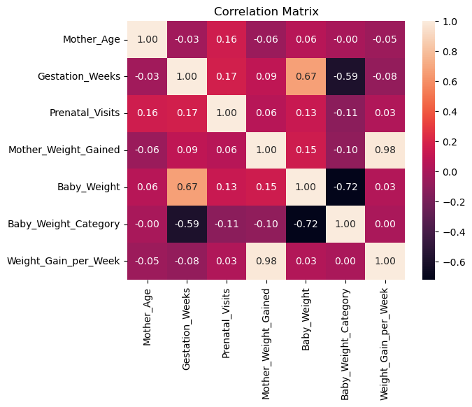

```python
sns.heatmap(df.select_dtypes(include='number').corr(), annot=True, fmt='.2f')
plt.title("Correlation Matrix")
plt.show()
```

Interpretation:

-Baby Weight is highly negatively correlated with the Baby Weight Category (r = -0.72), which is expected, since lower weight leads to a higher chance of being categorized as Low Birth Weight.

-Prenatal Visits show a weak positive correlation with Baby Weight (r = 0.13) and a weak negative correlation with Baby Weight Category (r = -0.11), implying a mild protective role of prenatal care.

```python
x = df[["Mother_Age", "Gestation_Weeks", "Prenatal_Visits", "Mother_Weight_Gained", "Mother_Maturity_younger mom", "Birth_Term_premie", "Marital_Status_not married", "Smoking_Status_smoker", "Race_white"]]
y = df["Baby_Weight_Category"]
```

```python
from sklearn.feature_selection import SelectKBest
from sklearn.feature_selection import chi2
from numpy import set_printoptions
test =SelectKBest(score_func=chi2, k=4)
fit=test.fit(x,y)
set_printoptions(precision=2)
print(fit.scores_)
```

```
[6.01e-03 7.69e+01 1.68e+01 6.57e+01 1.22e-01 2.66e+02 8.65e+00 1.30e+00
 1.86e+00]
```

```python
from sklearn.feature_selection import RFE
from sklearn.linear_model import LogisticRegression
model = LogisticRegression()
rfe = RFE(model, n_features_to_select=1)
fit=rfe.fit(x,y)
print(fit.ranking_)
```

```
[8 1 7 9 5 3 2 4 6]
```

```python
from sklearn.ensemble import ExtraTreesClassifier
model = ExtraTreesClassifier()
model.fit(x,y)
print(model.feature_importances_)
```

```
[0.14 0.24 0.15 0.16 0.01 0.24 0.02 0.02 0.02]
```

Interpretation:

-Based on the results from three feature selection methods—Chi-Square, Recursive Feature Elimination (RFE), and ExtraTreesClassifier—the most important predictors for determining baby weight category are Birth_Term_premie, Gestation_Weeks, Mother_Weight_Gained, Prenatal_Visits, and Marital_Status_not married.

-Gestation_Weeks also consistently ranked high, highlighting the importance of pregnancy duration in determining newborn weight. Mother_Weight_Gained and Prenatal_Visits reflect maternal nutrition and healthcare access, both of which are critical factors in fetal development.

-Additionally, Marital_Status_not married may act as a proxy for social and economic factors that indirectly influence birth outcomes. These five features not only showed strong statistical relevance but also align with medical knowledge, making them well-suited for building a predictive model for baby weight classificatio

MODEL EVALUATION

```python
from sklearn.model_selection import train_test_split
from sklearn.preprocessing import StandardScaler
from sklearn.metrics import classification_report, confusion_matrix, roc_auc_score, roc_curve
from sklearn.metrics import accuracy_score
```

```python
X = df[["Birth_Term_premie", "Gestation_Weeks", "Mother_Weight_Gained", "Prenatal_Visits", "Marital_Status_not married"]]
# Target Variable
y = df["Baby_Weight_Category"]
```

```python
X_train, X_test, y_train, y_test = train_test_split(X, y, test_size=0.2, random_state=42, stratify=y)
```

1. LOGISTIC REGRESSION

```python
from sklearn.linear_model import LogisticRegression
```

```python
#Fit the model
log_model = LogisticRegression()
log_model.fit(X_train, y_train)
```

```
LogisticRegression()
```

```python
# Predict and evaluate
log_y_pred = log_model.predict(X_test)
conf_matrix = confusion_matrix(y_test, log_y_pred)
class_report = classification_report(y_test, log_y_pred)
```

```python
print("Confusion Matrix:\n", conf_matrix)
print("\nClassification Report:\n", class_report)
```

```
Confusion Matrix:
 [[177   1]
 [ 10  12]]

Classification Report:
               precision    recall  f1-score   support

           0       0.95      0.99      0.97       178
           1       0.92      0.55      0.69        22

    accuracy                           0.94       200
   macro avg       0.93      0.77      0.83       200
weighted avg       0.94      0.94      0.94       200
```

```python
from sklearn.metrics import roc_auc_score
log_y_proba = log_model.predict_proba(X_test)[:, 1]
log_auc = roc_auc_score(y_test, log_y_proba)
print(f"Logistic Regression AUC-ROC: {log_auc:.2f}")
```

```
Logistic Regression AUC-ROC: 0.89
```

```python
# Accuracy
logistic_accuracy = accuracy_score(y_test, log_y_pred)
logistic_accuracy_percent = logistic_accuracy * 100
print(f"Logistic Regression Accuracy: {logistic_accuracy_percent:.2f}%")
```

```
Logistic Regression Accuracy: 94.50%
```

Interpretation:Logistic Regression offered the highest accuracy among all models and serves as a strong baseline. It helped interpret the influence of maternal features in a linear framework. However, its moderate recall indicates that while it predicts most normal weight babies correctly, it could miss some low-birth-weight cases.

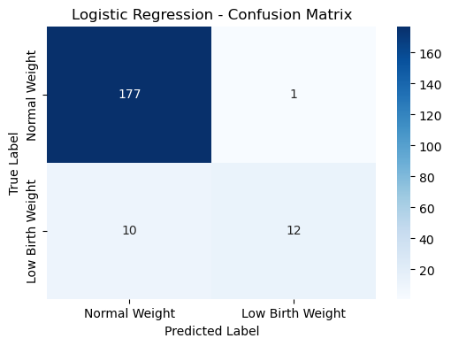

```python
cm = confusion_matrix(y_test, log_y_pred)
plt.figure(figsize=(6, 4))
sns.heatmap(cm, annot=True, fmt='d', cmap='Blues',
            xticklabels=['Normal Weight', 'Low Birth Weight'],
            yticklabels=['Normal Weight', 'Low Birth Weight'])
plt.title('Logistic Regression - Confusion Matrix')
plt.xlabel('Predicted Label')
plt.ylabel('True Label')
plt.show()
```

2. RANDOM FOREST

```python
from sklearn.ensemble import RandomForestClassifier
```

```python
scaler = StandardScaler()
X_train_scaled = scaler.fit_transform(X_train)
X_test_scaled = scaler.transform(X_test)
```

```python
# Fit the model
rf_model = RandomForestClassifier(n_estimators=100, class_weight='balanced')
rf_model.fit(X_train_scaled, y_train)
```

```
RandomForestClassifier(class_weight='balanced')
```

```python
#Predict and evaluate
y_pred = rf_model.predict(X_test_scaled)
y_proba = rf_model.predict_proba(X_test_scaled)[:, 1]
```

```python
print("Confusion Matrix:")
print(confusion_matrix(y_test, y_pred))

print("\nClassification Report:")
print(classification_report(y_test, y_pred))
```

```
Confusion Matrix:
[[176   2]
 [ 10  12]]

Classification Report:
              precision    recall  f1-score   support

           0       0.95      0.99      0.97       178
           1       0.86      0.55      0.67        22

    accuracy                           0.94       200
   macro avg       0.90      0.77      0.82       200
weighted avg       0.94      0.94      0.93       200
```

```python
rf_y_proba = rf_model.predict_proba(X_test_scaled)[:, 1]
rf_auc = roc_auc_score(y_test, rf_y_proba)
print(f"Random Forest AUC-ROC: {rf_auc:.2f}")
```

```
Random Forest AUC-ROC: 0.88
```

```python
rf_accuracy = accuracy_score(y_test, y_pred)
rf_accuracy_percent = rf_accuracy * 100
print(f"Random Forest Accuracy: {rf_accuracy_percent:.2f}%")
```

```
Random Forest Accuracy: 94.00%
```

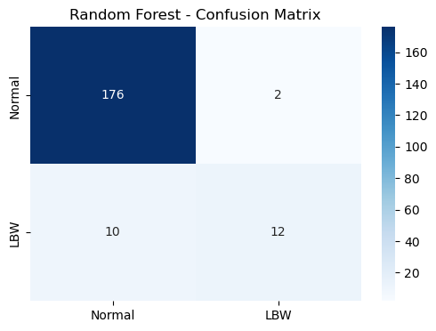

```python
cm = confusion_matrix(y_test, y_pred)

# Plot the heatmap
plt.figure(figsize=(6, 4))
sns.heatmap(cm, annot=True, fmt='d', cmap='Blues', xticklabels=['Normal', 'LBW'], yticklabels=['Normal', 'LBW'])
plt.title('Random Forest - Confusion Matrix')
plt.show()
```